# Assignment 4

James Guy

2023-10-29

```r
Pharmaceuticals <- read.csv("~/Masters Program/Fundamentals of Machine Learning/Assignment 4/Pharmaceuticals.csv")
```

```r
library(tidyverse)
library(factoextra)
library(ISLR)
set.seed(123)
```

```r
MC_Beta<-Pharmaceuticals[,c(3,4)]
```

```r
summary(MC_Beta)
```

```
##    Market_Cap          Beta
##  Min.   :  0.41   Min.   :0.1800
##  1st Qu.:  6.30   1st Qu.:0.3500
##  Median : 48.19   Median :0.4600
##  Mean   : 57.65   Mean   :0.5257
##  3rd Qu.: 73.84   3rd Qu.:0.6500
##  Max.   :199.47   Max.   :1.1100
```

I chose Market_Cap and Beta for the first cluster because I wanted to group the companies by their volatility and what the company is worth.

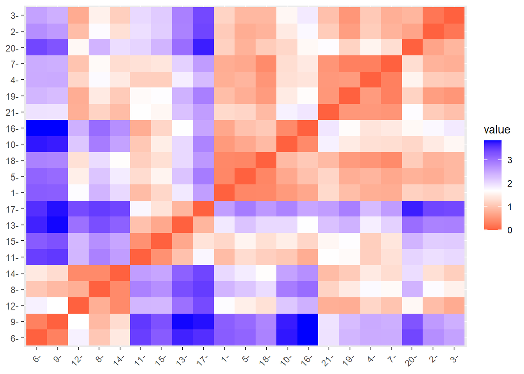

```r
MC_Beta<-scale(MC_Beta)
distance<-get_dist(MC_Beta)
fviz_dist(distance)
```

I used the silhouette method to choose the optimal number of clusters.

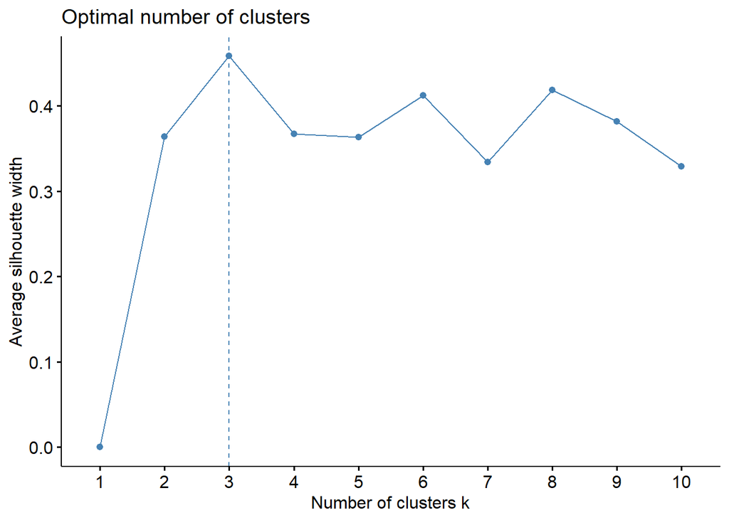

```r
fviz_nbclust(MC_Beta, kmeans, method = "silhouette")
```

```r
k4<-kmeans(MC_Beta,centers=3,nstart = 25)
k4$centers
```

```
##   Market_Cap       Beta
## 1  -0.909057  1.4110965
## 2  -0.186420 -0.5286048
## 3   1.695581 -0.1780563
```

```r
k4$size
```

```
## [1]  5 12  4
```

```r
k4$cluster[18]
```

```
## [1] 2
```

As can be seen from the plot below the red cluster tends to have higher beta, but a low market cap. This means that these companies have more volatile stock, but a lower market capitalization. The majority of the companies fall in cluster 2, showing that they have close to average beta and market cap.

The only pattern, with respect to variables 10-12, from the clusters below is that cluster 3 companies are all either moderate buy’s or holds.

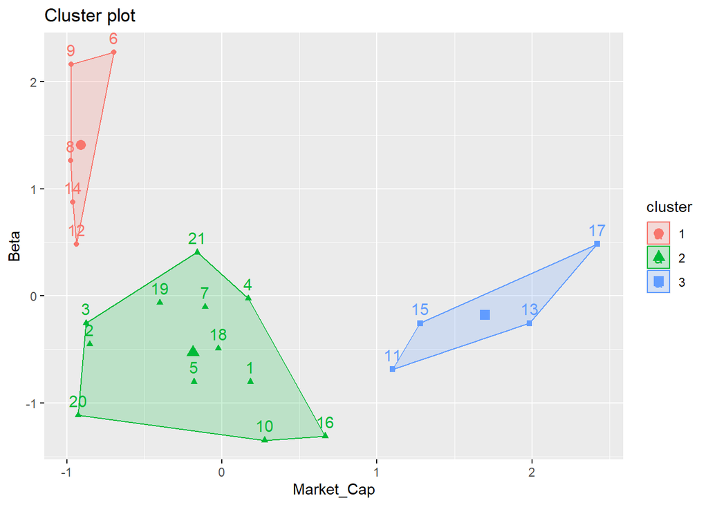

```r
fviz_cluster(k4,data = MC_Beta)
```

I chose PE_Ratio and ROE for the next cluster because I wanted to see where the companies were grouped by these metrics.

```r
PE_ROE<-Pharmaceuticals[,c(5,6)]
```

```r
summary(PE_ROE)
```

```
##     PE_Ratio          ROE
##  Min.   : 3.60   Min.   : 3.9
##  1st Qu.:18.90   1st Qu.:14.9
##  Median :21.50   Median :22.6
##  Mean   :25.46   Mean   :25.8
##  3rd Qu.:27.90   3rd Qu.:31.0
##  Max.   :82.50   Max.   :62.9
```

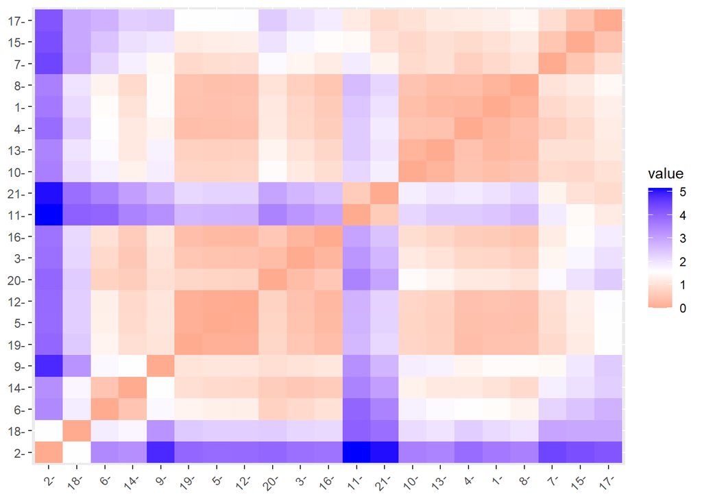

```r
PE_ROE<-scale(PE_ROE)
distance<-get_dist(PE_ROE)
fviz_dist(distance)
```

I used the silhouette method to choose the optimal number of clusters.

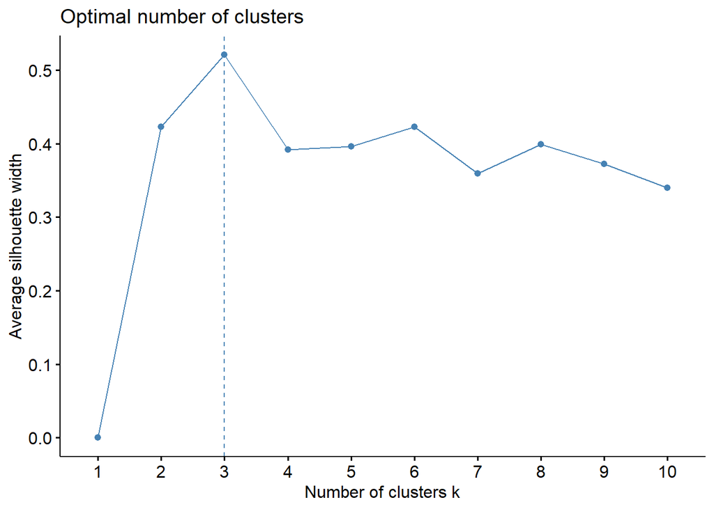

```r
fviz_nbclust(PE_ROE, kmeans, method = "silhouette")
```

```r
k4<-kmeans(PE_ROE,centers=3,nstart = 25)
k4$centers
```

```
##     PE_Ratio        ROE
## 1  2.7000246 -0.8349525
## 2 -0.2113774 -0.4007456
## 3 -0.4881532  1.4560688
```

```r
k4$size
```

```
## [1]  2 14  5
```

```r
k4$cluster[18]
```

```
## [1] 1
```

The pattern I see, with respect to variables 10-12, below is that cluster 3 companies are majorly from the US.

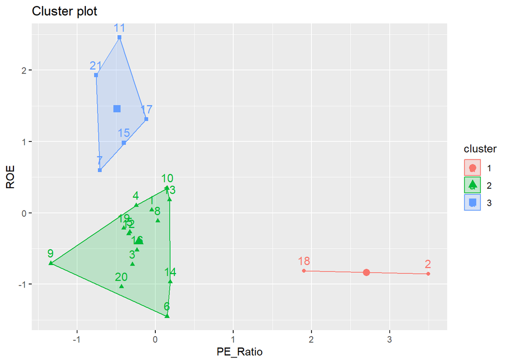

```r
fviz_cluster(k4,data = PE_ROE)
```

I chose ROA and Asset_Turnover for the next cluster because I wanted to see where the companies were grouped by these metrics.

```r
ROA_AT<-Pharmaceuticals[,c(7,8)]
```

```r
summary(ROA_AT)
```

```
##       ROA        Asset_Turnover
##  Min.   : 1.40   Min.   :0.3
##  1st Qu.: 5.70   1st Qu.:0.6
##  Median :11.20   Median :0.6
##  Mean   :10.51   Mean   :0.7
##  3rd Qu.:15.00   3rd Qu.:0.9
##  Max.   :20.30   Max.   :1.1
```

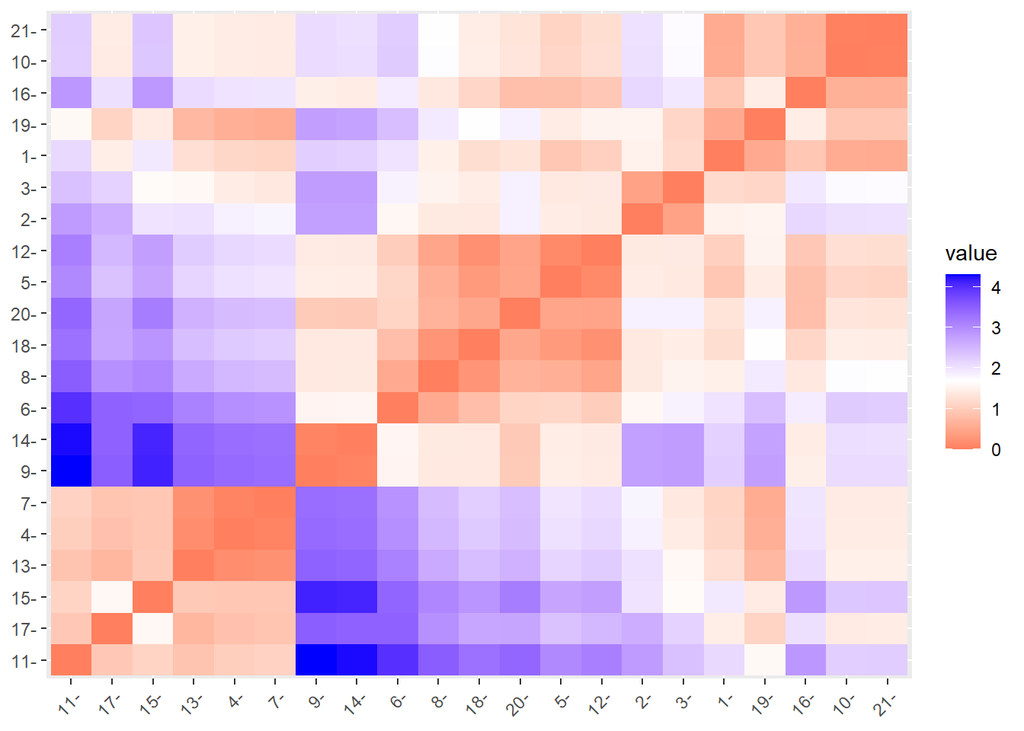

```r
ROA_AT<-scale(ROA_AT)
distance<-get_dist(ROA_AT)
fviz_dist(distance)
```

I used the silhouette method again to find the optimal number of clusters.

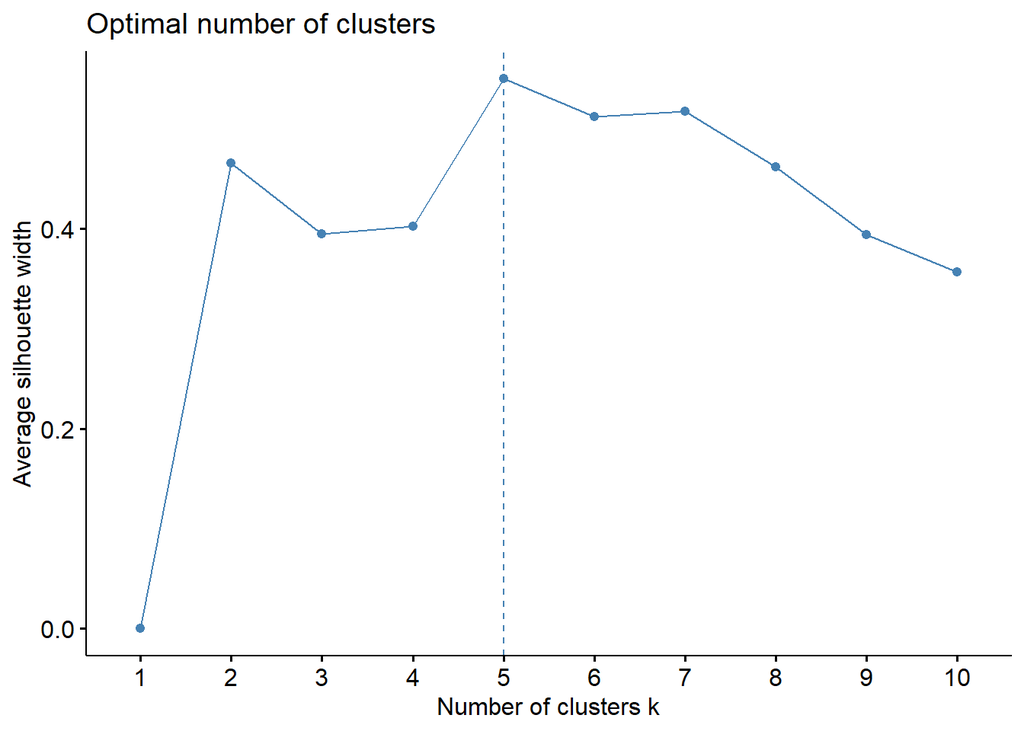

```r
fviz_nbclust(ROA_AT, kmeans, method = "silhouette")
```

```r
k4<-kmeans(ROA_AT,centers=5,nstart = 25)
k4$centers
```

```
##          ROA Asset_Turnover
## 1  1.1968747      1.0762864
## 2 -0.7261786      0.9225312
## 3  0.3994653     -0.2767594
## 4 -0.9579472     -0.5381432
## 5 -0.9892673     -1.8450624
```

```r
k4$size
```

```
## [1] 6 2 5 6 2
```

```r
k4$cluster[18]
```

```
## [1] 4
```

The pattern I see below, with respect to variables 10-12, is that the 4th cluster are majorly Moderate Buys and Holds.

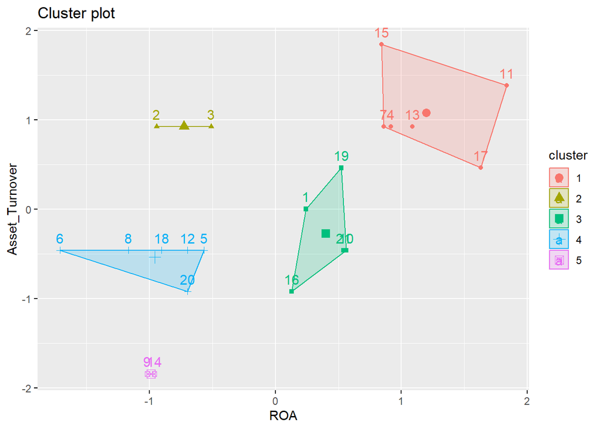

```r
fviz_cluster(k4,data = ROA_AT)
```

I chose Leverage and Rev_Growth for the next cluster.

```r
Lev_RG<-Pharmaceuticals[,c(9,10)]
```

```r
summary(Lev_RG)
```

```
##     Leverage        Rev_Growth
##  Min.   :0.0000   Min.   :-3.17
##  1st Qu.:0.1600   1st Qu.: 6.38
##  Median :0.3400   Median : 9.37
##  Mean   :0.5857   Mean   :13.37
##  3rd Qu.:0.6000   3rd Qu.:21.87
##  Max.   :3.5100   Max.   :34.21
```

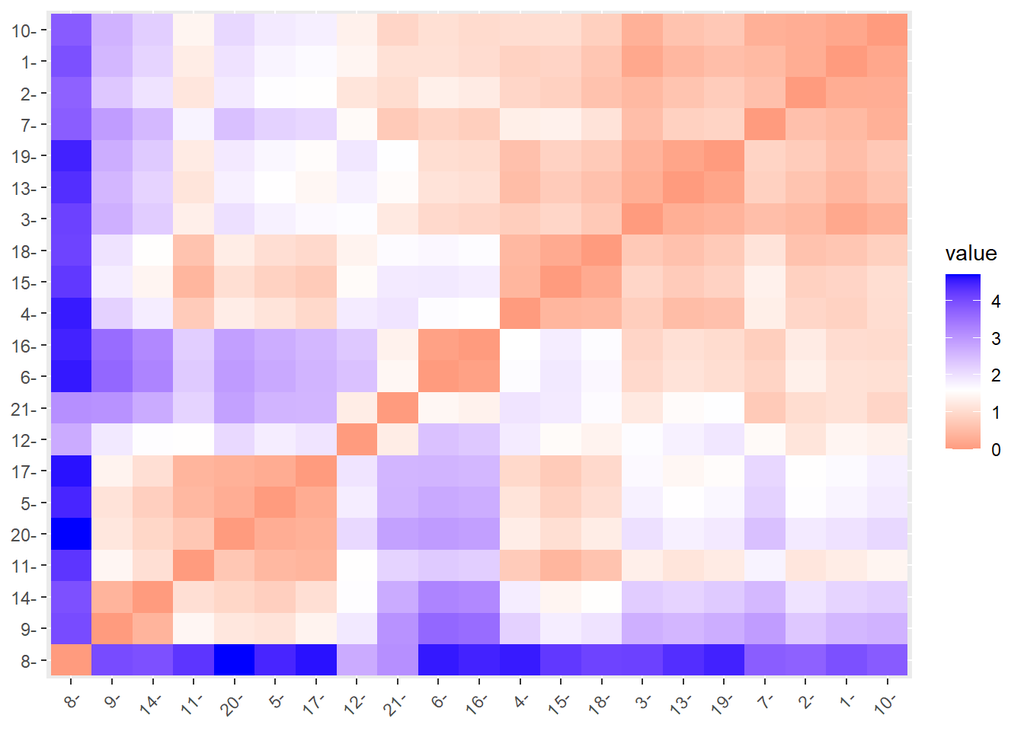

```r
Lev_RG<-scale(Lev_RG)
distance<-get_dist(Lev_RG)
fviz_dist(distance)
```

Once again I used the silhouette method for choosing the optimal amount of clusters, which turned out to be 7.

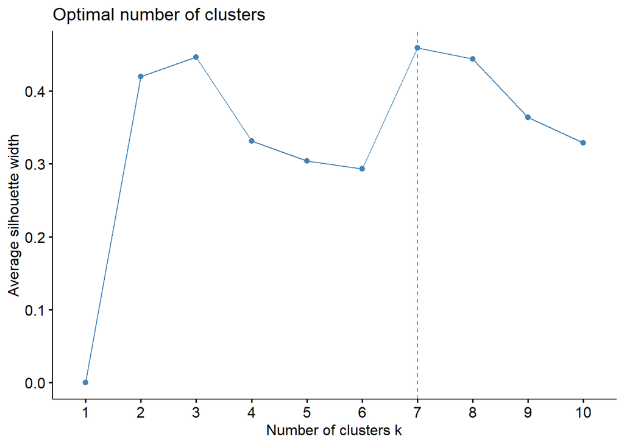

```r
fviz_nbclust(Lev_RG, kmeans, method = "silhouette")
```

```r
k4<-kmeans(Lev_RG,centers=7,nstart = 25)
k4$centers
```

```
##        Leverage  Rev_Growth
## 1 -0.0009142152 -0.71210902
## 2 -0.4168821332  1.12949575
## 3 -0.5627908798 -0.02850677
## 4  0.5302448185  1.71238901
## 5 -0.7112594290 -1.47542161
## 6  3.7427970467 -0.63276071
## 7  1.1062003973  0.05603085
```

```r
k4$size
```

```
## [1] 6 4 5 2 2 1 1
```

```r
k4$cluster[18]
```

```
## [1] 3
```

From the plot below we see that cluster 1 has 6 companies and they are all below average for Rev_Growth, but all very close to average for Leverage.

The pattern I see, with respect to variables 10-12, is that cluster 1 are majorly US companies, with only 2 of those companies being from the UK and Canada.

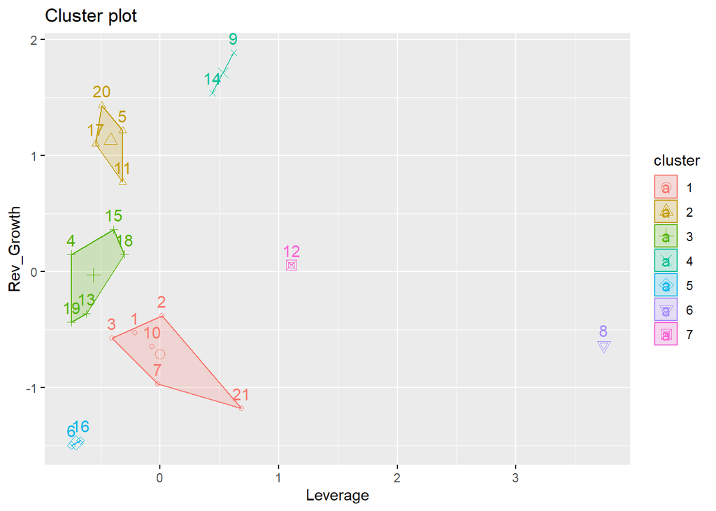

```r
fviz_cluster(k4,data = Lev_RG)
```

For the last cluster I chose the variables Rev_Growth and Net_Profit_Margin.

```r
RG_NPM<-Pharmaceuticals[,c(10,11)]
```

```r
summary(RG_NPM)
```

```
##    Rev_Growth    Net_Profit_Margin
##  Min.   :-3.17   Min.   : 2.6
##  1st Qu.: 6.38   1st Qu.:11.2
##  Median : 9.37   Median :16.1
##  Mean   :13.37   Mean   :15.7
##  3rd Qu.:21.87   3rd Qu.:21.1
##  Max.   :34.21   Max.   :25.5
```

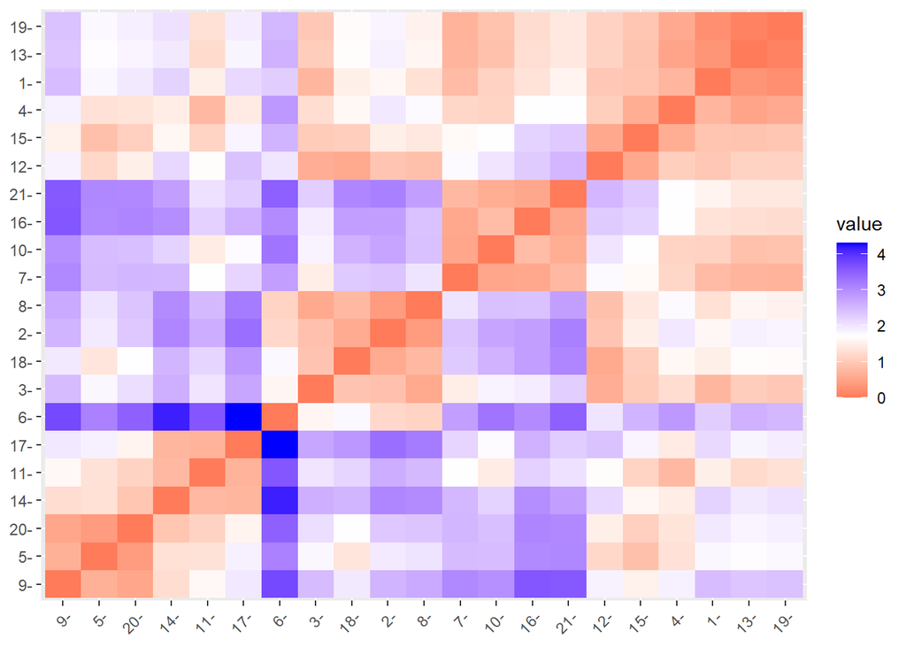

```r
RG_NPM<-scale(RG_NPM)
distance<-get_dist(RG_NPM)
fviz_dist(distance)
```

I used the silhouette method again to find the optimal number of clusters at 3.

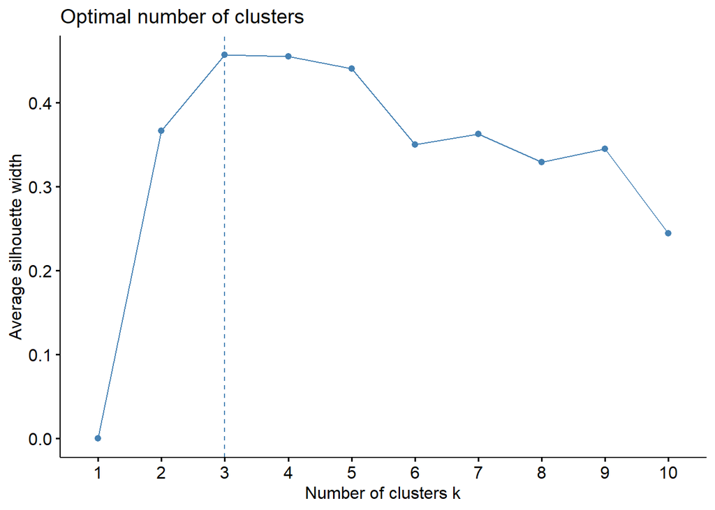

```r
fviz_nbclust(RG_NPM, kmeans, method = "silhouette")
```

```r
k4<-kmeans(RG_NPM,centers=3,nstart = 25)
k4$centers
```

```
##   Rev_Growth Net_Profit_Margin
## 1 -0.4799473        -1.2463443
## 2 -0.6779033         0.6845823
## 3  1.1861300         0.2859154
```

```r
k4$size
```

```
## [1] 6 8 7
```

```r
k4$cluster[18]
```

```
## [1] 1
```